# CSC478-Assignment4-BrundaChouthoy

```python
pwd
```

```
'/Users/Bru/Desktop/MS-PA/Spring2017/CSC478-ML/CSC478 - Assignments/HW4'
```

```python
import numpy as np
import pandas as pd
import matplotlib.pyplot as plt
%matplotlib inline
```

```python
cd segmentation_data
```

```
/Users/Bru/Desktop/MS-PA/Spring2017/CSC478-ML/CSC478 - Assignments/HW4/segmentation_data
```

# PCA for Reduced Dimensionality in Clustering [Dataset: segmentation_data.zip]

For this problem you will use an image segmentation data set for clustering. You will experiment with using PCA as an approach to reduce dimensionality and noise in the data. You will compare the results of clustering the data with and without PCA using the provided image class assignments as the ground truth. The data set is divided into three files. The file "segmentation_data.txt" contains data about images with each line corresponding to one image. Each image is represented by 19 features (these are the columns in the data and correspond to the feature names in the file "segmentation_names.txt". The file "segmentation_classes.txt" contains the class labels (the type of image) and a numeric class label for each of the corresponding images in the data file. After clustering the image data, you will use the class labels to measure completeness and homogeneity of the generated clusters. The data set used in this problem is based on the Image Segmentation data set at the UCI Machine Learning Repository.

# PART 1

### 1a) Load in the image data matrix (with rows as images and columns as features). Also load in the numeric class labels from the segmentation class file. Using your favorite method (e.g., sklearn's min-max scaler), perform min-max normalization on the data matrix so that each feature is scaled to [0,1] range.

```python
columns = pd.read_table('segmentation_names.txt', header=None)
columns
```

|  | 0 |
| --- | --- |
| 0 | REGION-CENTROID-COL |
| 1 | REGION-CENTROID-ROW |
| 2 | REGION-PIXEL-COUNT |
| 3 | SHORT-LINE-DENSITY-5 |
| 4 | SHORT-LINE-DENSITY-2 |
| 5 | VEDGE-MEAN |
| 6 | VEDGE-SD |
| 7 | HEDGE-MEAN |
| 8 | HEDGE-SD |
| 9 | INTENSITY-MEAN |
| 10 | RAWRED-MEAN |
| 11 | RAWBLUE-MEAN |
| 12 | RAWGREEN-MEAN |
| 13 | EXRED-MEAN |
| 14 | EXBLUE-MEAN |
| 15 | EXGREEN-MEAN |
| 16 | VALUE-MEAN |
| 17 | SATURATION-MEAN |
| 18 | HUE-MEAN |

```python
column_names = columns[0].tolist()
column_names
```

```
['REGION-CENTROID-COL',
 'REGION-CENTROID-ROW',
 'REGION-PIXEL-COUNT',
 'SHORT-LINE-DENSITY-5',
 'SHORT-LINE-DENSITY-2',
 'VEDGE-MEAN',
 'VEDGE-SD',
 'HEDGE-MEAN',
 'HEDGE-SD',
 'INTENSITY-MEAN',
 'RAWRED-MEAN',
 'RAWBLUE-MEAN',
 'RAWGREEN-MEAN',
 'EXRED-MEAN',
 'EXBLUE-MEAN',
 'EXGREEN-MEAN',
 'VALUE-MEAN',
 'SATURATION-MEAN',
 'HUE-MEAN']
```

```python
image_df = pd.read_table('segmentation_data.txt',header=None,names= column_names, sep=',')
image_df.head()
```

|  | REGION-CENTROID-COL | REGION-CENTROID-ROW | REGION-PIXEL-COUNT | SHORT-LINE-DENSITY-5 | SHORT-LINE-DENSITY-2 | VEDGE-MEAN | VEDGE-SD | HEDGE-MEAN | HEDGE-SD | INTENSITY-MEAN | RAWRED-MEAN | RAWBLUE-MEAN | RAWGREEN-MEAN | EXRED-MEAN | EXBLUE-MEAN | EXGREEN-MEAN | VALUE-MEAN | SATURATION-MEAN | HUE-MEAN |
| --- | --- | --- | --- | --- | --- | --- | --- | --- | --- | --- | --- | --- | --- | --- | --- | --- | --- | --- | --- |
| 0 | 110.0 | 189.0 | 9 | 0.0 | 0.0 | 1.000000 | 0.666667 | 1.222222 | 1.186342 | 12.925926 | 10.888889 | 9.222222 | 18.666668 | -6.111111 | -11.111111 | 17.222221 | 18.666668 | 0.508139 | 1.910864 |
| 1 | 86.0 | 187.0 | 9 | 0.0 | 0.0 | 1.111111 | 0.720082 | 1.444444 | 0.750309 | 13.740741 | 11.666667 | 10.333334 | 19.222221 | -6.222222 | -10.222222 | 16.444445 | 19.222221 | 0.463329 | 1.941465 |
| 2 | 225.0 | 244.0 | 9 | 0.0 | 0.0 | 3.388889 | 2.195113 | 3.000000 | 1.520234 | 12.259259 | 10.333334 | 9.333334 | 17.111110 | -5.777778 | -8.777778 | 14.555555 | 17.111110 | 0.480149 | 1.987902 |
| 3 | 47.0 | 232.0 | 9 | 0.0 | 0.0 | 1.277778 | 1.254621 | 1.000000 | 0.894427 | 12.703704 | 11.000000 | 9.000000 | 18.111110 | -5.111111 | -11.111111 | 16.222221 | 18.111110 | 0.500966 | 1.875362 |
| 4 | 97.0 | 186.0 | 9 | 0.0 | 0.0 | 1.166667 | 0.691215 | 1.166667 | 1.005540 | 15.592592 | 13.888889 | 11.777778 | 21.111110 | -5.111111 | -11.444445 | 16.555555 | 21.111110 | 0.442661 | 1.863654 |

```python
image_df.shape
```

```
(2100, 19)
```

```python
class_df = pd.read_table('segmentation_classes.txt',header=None, sep='\t')
class_df.head()
```

|  | 0 | 1 |
| --- | --- | --- |
| 0 | GRASS | 0 |
| 1 | GRASS | 0 |
| 2 | GRASS | 0 |
| 3 | GRASS | 0 |
| 4 | GRASS | 0 |

```python
class_df.shape
```

```
(2100, 2)
```

```python
from sklearn import preprocessing

#fit and transform the data
image_normalized = preprocessing.MinMaxScaler().fit_transform(image_df)

np.set_printoptions(precision=2, linewidth=80, suppress=True)
image_normalized[0:5]
```

```
array([[ 0.43,  0.74,  0.  ,  0.  ,  0.  ,  0.03,  0.  ,  0.03,  0.  ,  0.09,
         0.08,  0.06,  0.13,  0.73,  0.01,  0.87,  0.12,  0.51,  0.83],
       [ 0.34,  0.73,  0.  ,  0.  ,  0.  ,  0.04,  0.  ,  0.03,  0.  ,  0.1 ,
         0.09,  0.07,  0.13,  0.73,  0.02,  0.86,  0.13,  0.46,  0.84],
       [ 0.89,  0.97,  0.  ,  0.  ,  0.  ,  0.12,  0.  ,  0.07,  0.  ,  0.09,
         0.08,  0.06,  0.12,  0.74,  0.04,  0.83,  0.11,  0.48,  0.84],
       [ 0.18,  0.92,  0.  ,  0.  ,  0.  ,  0.04,  0.  ,  0.02,  0.  ,  0.09,
         0.08,  0.06,  0.13,  0.75,  0.01,  0.86,  0.12,  0.5 ,  0.83],
       [ 0.38,  0.73,  0.  ,  0.  ,  0.  ,  0.04,  0.  ,  0.03,  0.  ,  0.11,
         0.1 ,  0.08,  0.15,  0.75,  0.01,  0.86,  0.14,  0.44,  0.82]])
```

All the features are normalized to the value between 0 and 1. Default range to standardize MinMaxScaler is 0 to 1.

### 1b) Next, Perform Kmeans clustering (for this problem, use the Kmeans implementation in scikit-learn) on the image data (since there are a total 7 pre-assigned image classes, you should use K = 7 in your clustering). Use Euclidean distance as your distance measure for the clustering. Print the cluster centroids (use some formatting so that they are visually understandable). Compare your 7 clusters to the 7 pre-assigned classes by computing the Completeness and Homogeneity values of the generated clusters.

```python
import sklearn
from sklearn.cluster import KMeans

kmeans = sklearn.cluster.KMeans(n_clusters=7).fit(image_normalized) #Number of clusters=7
```

```python
kmeans.labels_
```

```
array([4, 4, 4, ..., 0, 0, 2], dtype=int32)
```

```python
kmeans.cluster_centers_
```

```
array([[ 0.77,  0.43,  0.  ,  0.01,  0.02,  0.04,  0.  ,  0.02,  0.  ,  0.04,
         0.04,  0.06,  0.03,  0.78,  0.22,  0.49,  0.06,  0.54,  0.24],
       [ 0.54,  0.15,  0.  ,  0.03,  0.  ,  0.03,  0.  ,  0.03,  0.  ,  0.82,
         0.78,  0.89,  0.79,  0.27,  0.67,  0.29,  0.89,  0.21,  0.13],
       [ 0.26,  0.39,  0.  ,  0.07,  0.02,  0.08,  0.  ,  0.06,  0.  ,  0.15,
         0.14,  0.19,  0.12,  0.72,  0.34,  0.36,  0.19,  0.41,  0.2 ],
       [ 0.75,  0.53,  0.  ,  0.04,  0.04,  0.11,  0.02,  0.11,  0.02,  0.3 ,
         0.28,  0.35,  0.27,  0.59,  0.45,  0.31,  0.35,  0.3 ,  0.16],
       [ 0.51,  0.81,  0.  ,  0.08,  0.01,  0.05,  0.  ,  0.05,  0.  ,  0.11,
         0.09,  0.09,  0.14,  0.68,  0.08,  0.82,  0.13,  0.41,  0.89],
       [ 0.3 ,  0.53,  0.  ,  0.05,  0.05,  0.1 ,  0.01,  0.08,  0.01,  0.4 ,
         0.37,  0.47,  0.35,  0.5 ,  0.57,  0.21,  0.47,  0.3 ,  0.16],
       [ 0.25,  0.46,  0.  ,  0.03,  0.01,  0.04,  0.  ,  0.03,  0.  ,  0.03,
         0.02,  0.04,  0.02,  0.77,  0.22,  0.51,  0.04,  0.8 ,  0.18]])
```

```python
#Converting cluster centers array to dataframe and trasposing it so that features are rows and clusters are columns
#Providing it with column_names (features) as 'index' and Cluster Names as 'columns'

pd.DataFrame(kmeans.cluster_centers_.T, index=column_names, columns=['Cluster 1', 'Cluster 2','Cluster 3','Cluster 4','Cluster 5',' Cluster 6','Cluster 7'])
```

|  | Cluster 1 | Cluster 2 | Cluster 3 | Cluster 4 | Cluster 5 | Cluster 6 | Cluster 7 |
| --- | --- | --- | --- | --- | --- | --- | --- |
| REGION-CENTROID-COL | 0.770674 | 0.535099 | 0.256103 | 0.750696 | 0.513994 | 0.302506 | 0.254169 |
| REGION-CENTROID-ROW | 0.425215 | 0.150167 | 0.393468 | 0.534564 | 0.808937 | 0.530862 | 0.459974 |
| REGION-PIXEL-COUNT | 0.000000 | 0.000000 | 0.000000 | 0.000000 | 0.000000 | 0.000000 | 0.000000 |
| SHORT-LINE-DENSITY-5 | 0.013978 | 0.027778 | 0.074510 | 0.040000 | 0.077441 | 0.052260 | 0.026256 |
| SHORT-LINE-DENSITY-2 | 0.022581 | 0.001667 | 0.019118 | 0.038462 | 0.005051 | 0.046610 | 0.013699 |
| VEDGE-MEAN | 0.040237 | 0.030228 | 0.077343 | 0.114419 | 0.054474 | 0.100817 | 0.037274 |
| VEDGE-SD | 0.002989 | 0.000543 | 0.004100 | 0.019301 | 0.001407 | 0.009420 | 0.002364 |
| HEDGE-MEAN | 0.023122 | 0.026766 | 0.060574 | 0.109240 | 0.046335 | 0.083972 | 0.027874 |
| HEDGE-SD | 0.002088 | 0.000587 | 0.004967 | 0.017999 | 0.001401 | 0.011043 | 0.002017 |
| INTENSITY-MEAN | 0.041138 | 0.823246 | 0.148187 | 0.300955 | 0.108790 | 0.400608 | 0.026013 |
| RAWRED-MEAN | 0.035005 | 0.779716 | 0.138085 | 0.279908 | 0.091403 | 0.370347 | 0.017925 |
| RAWBLUE-MEAN | 0.058340 | 0.894170 | 0.185160 | 0.352738 | 0.092414 | 0.472461 | 0.042306 |
| RAWGREEN-MEAN | 0.028766 | 0.788761 | 0.118539 | 0.265920 | 0.142676 | 0.353036 | 0.016504 |
| EXRED-MEAN | 0.778473 | 0.270665 | 0.716906 | 0.592572 | 0.679161 | 0.497146 | 0.769800 |
| EXBLUE-MEAN | 0.223939 | 0.666373 | 0.344014 | 0.451124 | 0.079002 | 0.570882 | 0.216011 |
| EXGREEN-MEAN | 0.486509 | 0.289386 | 0.355458 | 0.309158 | 0.821287 | 0.213054 | 0.508117 |
| VALUE-MEAN | 0.059295 | 0.894170 | 0.185413 | 0.352822 | 0.134901 | 0.472461 | 0.043295 |
| SATURATION-MEAN | 0.538181 | 0.211804 | 0.411986 | 0.302342 | 0.414491 | 0.302263 | 0.801687 |
| HUE-MEAN | 0.243969 | 0.125066 | 0.201890 | 0.164764 | 0.892333 | 0.163879 | 0.181153 |

Cluster centers for all 7 clusters is shown in the dataframe above.

```python
from sklearn.metrics import completeness_score, homogeneity_score

completeness = completeness_score(class_df[1], kmeans.labels_)
homogeneity = homogeneity_score(class_df[1], kmeans.labels_)

print('Completeness of Cluster: '+  str(completeness))
print('Homogeneity of Clusters: '+ str(homogeneity))
```

```
Completeness of Cluster: 0.613187012485
Homogeneity of Clusters: 0.611502116337
```

## 1c) Perform PCA on the normalized image data matrix. You may use the linear algebra package in Numpy or the Decomposition module in scikit-learn (the latter is much more efficient). Analyze the principal components to determine the number, r, of PCs needed to capture at least 95% of variance in the data. Then use these r components as features to transform the data into a reduced dimension space. [See the PCA Clustering Notebook from class for an example of how these steps are performed.]

```python
from sklearn.decomposition import PCA

pca = PCA(n_components=10)
pca_model = pca.fit_transform(image_normalized) #Fit the model and apply dimensionality reduction on the image data
print(pca_model)
```

```
[[-0.69  0.53  0.25 ..., -0.    0.   -0.  ]
 [-0.67  0.51  0.34 ..., -0.02  0.   -0.01]
 [-0.71  0.77 -0.16 ...,  0.05 -0.05  0.04]
 ...,
 [-0.51 -0.13 -0.08 ...,  0.03 -0.01 -0.08]
 [-0.48 -0.09 -0.16 ...,  0.03 -0.03 -0.05]
 [-0.44 -0.11 -0.05 ...,  0.13 -0.05 -0.11]]
```

```python
print(pca.explained_variance_ratio_)
```

```
[ 0.61  0.13  0.1   0.05  0.04  0.02  0.02  0.02  0.01  0.01]
```

So we can sum it up manually and can see that first 7 components are capturing at least 95% variance in the data. Now let's visualize the same and then computed the total variance captured.

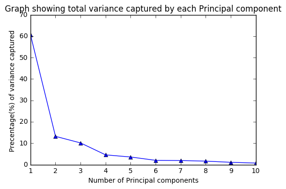

```python
fig = plt.figure()
ax = fig.add_subplot(111)
ax.plot(range(1, 11), pca.explained_variance_ratio_*100, marker='^')
plt.xlabel('Number of Principal components')
plt.ylabel('Precentage(%) of variance captured ')
plt.title('Graph showing total variance captured by each Principal component')
plt.show()
```

```python
pc=0
total_var=0
for i in pca.explained_variance_ratio_:
    pc = pc+1
    total_var = total_var + (i*100)
    print("The variance captured by PC",pc,"is",total_var)
```

```
The variance captured by PC 1 is 60.7142339685
The variance captured by PC 2 is 73.9112132017
The variance captured by PC 3 is 84.0349861426
The variance captured by PC 4 is 88.5785253433
The variance captured by PC 5 is 92.1258864811
The variance captured by PC 6 is 94.1139219796
The variance captured by PC 7 is 96.005892277
The variance captured by PC 8 is 97.6213010819
The variance captured by PC 9 is 98.6869019336
The variance captured by PC 10 is 99.3982394515
```

As shown above, 96.0058% variance of the data is captured by 7 principal components.

```python
pca = PCA(n_components=7)
pca_trans = pca.fit_transform(image_df)
print(pca_trans)
```

```
[[ -84.65   -4.43   -8.88 ...,    2.71   27.51    6.69]
 [ -84.35  -28.54   -7.58 ...,    3.33   26.87    6.55]
 [ -96.16  115.47  -17.9  ...,    4.36   19.05    2.6 ]
 ...,
 [ -78.74   10.28   -9.03 ...,    0.69   -4.83   -1.91]
 [ -72.94   31.66   -9.31 ...,    1.2    -4.48   -2.93]
 [ -72.7     6.09   -7.91 ...,    1.18   -6.44   -1.54]]
```

```python
print(pca.explained_variance_ratio_)
```

```
[ 0.42  0.24  0.19  0.1   0.03  0.01  0.  ]
```

```python
pca_trans.shape #2100 samples and 7 principal components
```

```
(2100, 7)
```

## 1d) Perform Kmeans again, but this time on the lower dimensional transformed data. Then, compute the Completeness and Homogeneity values of the new clusters.

```python
#using the lower dimensional transformed data
kmeans = sklearn.cluster.KMeans(n_clusters=7).fit(pca_trans) #Number of clusters=7
```

```python
kmeans.labels_
```

```
array([2, 2, 0, ..., 0, 0, 0], dtype=int32)
```

```python
kmeans.cluster_centers_
```

```
array([[ -62.16,   75.94,   -9.28,   17.68,   -1.03,    6.13,    1.15],
       [ 167.48,  -73.64,   -7.01,    0.49,    1.11,    3.75,    2.59],
       [ -48.22,  -47.8 ,   -4.02,  -66.61,    2.75,    2.62,    1.93],
       [ -51.83,  -62.55,    3.39,   30.92,   -0.44,   -1.97,   -1.04],
       [  53.9 ,   62.29,  762.18,  -16.17,   50.56,    5.38,   -0.25],
       [  19.72,   54.06,   -2.28,  -16.05,   -1.95,  -11.52,   -3.67],
       [ 209.95,   48.13,  -16.18,    4.48,   -0.74,    7.72,    2.68]])
```

```python
#Converting cluster centers array to dataframe and trasposing it so that components are rows and clusters are columns
#Providing it with column_names (features) as 'index' and Cluster Names as 'columns'

pd.DataFrame(kmeans.cluster_centers_.T, index=['PC 1','PC 2','PC 3','PC 4', 'PC 5', 'PC 6', 'PC 7'], columns=['Cluster 1', 'Cluster 2','Cluster 3','Cluster 4','Cluster 5',' Cluster 6','Cluster 7'])
```

|  | Cluster 1 | Cluster 2 | Cluster 3 | Cluster 4 | Cluster 5 | Cluster 6 | Cluster 7 |
| --- | --- | --- | --- | --- | --- | --- | --- |
| PC 1 | -62.157363 | 167.484080 | -48.216151 | -51.829625 | 53.897922 | 19.717186 | 209.945750 |
| PC 2 | 75.940907 | -73.641745 | -47.795319 | -62.549971 | 62.290196 | 54.064645 | 48.131278 |
| PC 3 | -9.284021 | -7.008937 | -4.019389 | 3.392802 | 762.180560 | -2.282896 | -16.184293 |
| PC 4 | 17.683845 | 0.491909 | -66.605648 | 30.915400 | -16.174302 | -16.049682 | 4.479261 |
| PC 5 | -1.025148 | 1.113922 | 2.745963 | -0.436541 | 50.555912 | -1.948863 | -0.739979 |
| PC 6 | 6.128069 | 3.752368 | 2.618510 | -1.972126 | 5.384313 | -11.524799 | 7.715566 |
| PC 7 | 1.151455 | 2.591288 | 1.926329 | -1.044200 | -0.253590 | -3.670525 | 2.676320 |

```python
completeness = completeness_score(class_df[1], kmeans.labels_)
homogeneity = homogeneity_score(class_df[1], kmeans.labels_)

print('Completeness of Cluster: '+  str(completeness))
print('Homogeneity of Clusters: '+ str(homogeneity))
```

```
Completeness of Cluster: 0.542114160731
Homogeneity of Clusters: 0.480046676446
```

## 1e) Discuss your observations based on the comparison of the two clustering results.

When kmeans clustering is performed on normalized image data with all the 19 features, the completeness and homogeneity is shown below:

```
Completeness of Cluster: 0.613187012485
Homogeneity of Clusters: 0.611502116337
```

When kmeans clustering is performed on the image dataset with reduced uncorrelated features that are created using PCA, and captures the most of the variance in the data, the completeness and homogeneity is shown below:

```
Completeness of Cluster: 0.542114160731
Homogeneity of Clusters: 0.480046676446
```

# PART 2

# Association Rule Discovery [Dataset: playlists.zip]

For this problem you will experiment with association rule mining using Apriori algorithm discussed in class. You will use a modified version of the Apriori implementation in Machine Learning in Action (it has been modified to compute lift values for rules in addition to confidence). [See Associations Notebook from class for an example of using this module.]

The data set you will use is based on a music playlist data set obtained from Yes.com. [See the full description of this data]. We will only use a portion of this data. The provided data archive contains two files. The file "playlists.txt" contains on each line a sequence of songs played as part of one playlist. The songs are represented by integer values. The file "song_names.txt" contains the mapping between the integer codes and song tiles and artists (format of the song names is [song title]::[artist]). You will need both of these files to generate association rules.

```python
pwd
```

```
'/Users/Bru/Desktop/MS-PA/Spring2017/CSC478-ML/CSC478 - Assignments/HW4/segmentation_data'
```

```python
cd ..
```

```
/Users/Bru/Desktop/MS-PA/Spring2017/CSC478-ML/CSC478 - Assignments/HW4
```

```python
cd playlists
```

```
/Users/Bru/Desktop/MS-PA/Spring2017/CSC478-ML/CSC478 - Assignments/HW4/playlists
```

## 1a) Load the playlist data into a Python nested list, and the song_names data into an appropriate data structure.

```python
playlist_df = pd.read_table('playlists.txt',header=None)
playlist_df.shape
```

```
(41480, 1)
```

```python
playlist_df.head()
```

|  | 0 |
| --- | --- |
| 0 | 0 1 2 3 4 5 6 7 8 |
| 1 | 9 10 11 |
| 2 | 12 13 14 15 |
| 3 | 16 17 18 |
| 4 | 19 |

```python
playlist_data = []
for line in open('playlists.txt'):
    x = [int(x) for x in line.split()]
    playlist_data.append(x)
```

```python
playlist_data
```

[output not shown]

[output cut: 1908 more lines]

[output not shown]

```python
songs_data = pd.read_table('song_names.txt',header=None,sep='\t')
songs_data.head()
```

|  | 0 | 1 |
| --- | --- | --- |
| 0 | 0 | Gucci-Time::Gucci-Mane |
| 1 | 1 | Aston-Martin-Music::Rick-Ross |
| 2 | 2 | Get-Back-Up::T.I. |
| 3 | 3 | Hot-Toddy::Usher |
| 4 | 4 | Whip-My-Hair::Willow |

```python
songs_data.shape
```

```
(3168, 2)
```

## 1b) Run Apriori on the playlist data using a min-support value of 0.002.

```python
'''
Created on Mar 24, 2011
Ch 11 code
@author: Peter
'''
from numpy import *

def loadDataSet():
    return [[1, 3, 4], [2, 3, 5], [1, 2, 3, 5], [2, 5]]

def createC1(dataSet):
    C1 = []
    for transaction in dataSet:
        for item in transaction:
            if not [item] in C1:
                C1.append([item])

    C1.sort()
    return list(map(frozenset, C1))#use frozen set so we
                            #can use it as a key in a dict

def scanD(D, Ck, minSupport):
    ssCnt = {}
    for tid in D:
        for can in Ck:
            if can.issubset(tid):
                if can not in ssCnt: ssCnt[can]=1
                else: ssCnt[can] += 1
    numItems = float(len(D))
    retList = []
    supportData = {}
    for key in ssCnt:
        support = ssCnt[key]/numItems
        if support >= minSupport:
            retList.insert(0,key)
        supportData[key] = support
    return retList, supportData

def aprioriGen(Lk, k): #creates Ck
    retList = []
    lenLk = len(Lk)
    for i in range(lenLk):
        for j in range(i+1, lenLk):
            L1 = list(Lk[i])[:k-2]; L2 = list(Lk[j])[:k-2]
            L1.sort(); L2.sort()
            if L1==L2: #if first k-2 elements are equal
                retList.append(Lk[i] | Lk[j]) #set union
    return retList

def apriori(dataSet, minSupport):
    C1 = createC1(dataSet)
    D = list(map(set, dataSet))
    L1, supportData = scanD(D, C1, minSupport)
    L = [L1]
    k = 2
    while (len(L[k-2]) > 0):
        Ck = aprioriGen(L[k-2], k)
        Lk, supK = scanD(D, Ck, minSupport)#scan DB to get Lk
        supportData.update(supK)
        L.append(Lk)
        k += 1
    return L, supportData

def generateRules(L, supportData, metric='confidence', minMetric=0.7):  #supportData is a dict coming from scanD
    bigRuleList = []
    for i in range(1, len(L)):#only get the sets with two or more items
        for freqSet in L[i]:
            H1 = [frozenset([item]) for item in freqSet]
            if (i > 1):
                rulesFromConseq(freqSet, H1, supportData, bigRuleList, metric, minMetric)
            else:
                calcMetric(freqSet, H1, supportData, bigRuleList, metric, minMetric)
    return bigRuleList

def calcMetric(freqSet, H, supportData, brl, metric='confidence', minMetric=0.7):
    prunedH = [] #create new list to return
    for conseq in H:
        conf = supportData[freqSet]/supportData[freqSet-conseq] #calc confidence
        lift = conf/supportData[conseq] #calc lift
        if (metric == 'confidence'):
            if (conf >= minMetric):
                print (freqSet-conseq,'-->',conseq,'conf:',conf,' lift:',lift)
                brl.append((freqSet-conseq, conseq, conf, lift))
                prunedH.append(conseq)
        elif (metric == 'lift'):
            if (lift >= minMetric):
                print (freqSet-conseq,'-->',conseq,'conf:',conf,' lift:',lift)
                brl.append((freqSet-conseq, conseq, conf, lift))
                prunedH.append(conseq)
    return prunedH

def rulesFromConseq(freqSet, H, supportData, brl, metric='confidence', minMetric=0.7):
    m = len(H[0])
    if (len(freqSet) > (m + 1)): #try further merging
        Hmp1 = aprioriGen(H, m+1)#create Hm+1 new candidates
        Hmp1 = calcMetric(freqSet, Hmp1, supportData, brl, metric, minMetric)
        if (len(Hmp1) > 1):    #need at least two sets to merge
            rulesFromConseq(freqSet, Hmp1, supportData, brl, metric, minMetric)

def pntRules(ruleList, itemMeaning):
    for ruleTup in ruleList:
        for item in ruleTup[0]:
            print (itemMeaning[item])
        print ("           -------->")
        for item in ruleTup[1]:
            print (itemMeaning[item])
        print ("[confidence: %f, lift: %f]" % (ruleTup[2], ruleTup[3]))
        print ()    #print a blank line
```

Made a few changes to the code, as has_key is no longer valid in Python 3.x so changed it key not in, also map returns a generater and not a list in Python 3.x so explicitely converted all maps to list using list(map(....)).

```python
L, support = apriori(playlist_data, 0.002)
```

```python
print(L)
```

[output not shown]

```python
print(support)
```

[output not shown]

## 1c) Generate rules from the frequent itemsets discovered in the previous step (you can try different metrics ('lift' or 'confidence' to see which gives you more useful and interesting results). At minimum, you should generate rules with a minimum lift value of 20.0. If you use confidence, you may want to set the min-confidence threshold to about 0.5.

```python
ruleList = generateRules(L, support, metric='confidence', minMetric=0.5)
```

```
frozenset({2883}) --> frozenset({2878}) conf: 0.5281385281385281  lift: 49.90247413937619
frozenset({2826}) --> frozenset({2839}) conf: 0.6175115207373272  lift: 35.18458500025321
frozenset({2878}) --> frozenset({5}) conf: 0.5353075170842825  lift: 32.70184949728429
frozenset({2774}) --> frozenset({2018}) conf: 0.5149253731343284  lift: 34.843563585011324
frozenset({2840}) --> frozenset({2839}) conf: 0.511727078891258  lift: 29.15719674781509
frozenset({2878}) --> frozenset({2839}) conf: 0.5079726651480638  lift: 28.943277679040783
frozenset({2826}) --> frozenset({5}) conf: 0.5852534562211981  lift: 35.75303882776921
frozenset({44}) --> frozenset({2018}) conf: 0.5025380710659899  lift: 34.00534940916356
frozenset({2871}) --> frozenset({5}) conf: 0.5352941176470587  lift: 32.70103092783504
frozenset({5}) --> frozenset({2839}) conf: 0.5110456553755522  lift: 29.118370583760864
frozenset({2871}) --> frozenset({2839}) conf: 0.5058823529411764  lift: 28.824175824175825
frozenset({2883}) --> frozenset({5}) conf: 0.5108225108225108  lift: 31.206064431395802
frozenset({2512}) --> frozenset({20}) conf: 0.5240384615384615  lift: 33.23717948717948
frozenset({3018}) --> frozenset({3016}) conf: 0.6935483870967741  lift: 243.79989065062873
frozenset({3016}) --> frozenset({3018}) conf: 0.7288135593220338  lift: 243.79989065062873
frozenset({2832}) --> frozenset({5}) conf: 0.6046511627906976  lift: 36.93804157961434
frozenset({2781}) --> frozenset({2839}) conf: 0.5054945054945055  lift: 28.802077043835286
frozenset({2832}) --> frozenset({2839}) conf: 0.622093023255814  lift: 35.445629951443905
frozenset({89, 2781}) --> frozenset({5, 2839}) conf: 0.5670731707317073  lift: 67.78730582694877
frozenset({89, 2839}) --> frozenset({2781, 5}) conf: 0.5081967213114754  lift: 81.07692307692308
frozenset({2018, 2781}) --> frozenset({5, 2839}) conf: 0.6174496644295302  lift: 73.80925671624472
frozenset({2018, 2839}) --> frozenset({2781, 5}) conf: 0.5257142857142857  lift: 83.87164835164835
frozenset({2018, 5}) --> frozenset({2781, 2839}) conf: 0.5082872928176796  lift: 76.39042357274401
frozenset({6, 2839}) --> frozenset({80, 5}) conf: 0.5  lift: 87.14285714285715
frozenset({89, 2878}) --> frozenset({5, 2839}) conf: 0.6122448979591837  lift: 73.18708463212376
frozenset({80, 2878}) --> frozenset({5, 2839}) conf: 0.6666666666666666  lift: 79.6926032660903
frozenset({20, 2781}) --> frozenset({5, 2839}) conf: 0.5028571428571429  lift: 60.110992177850974
frozenset({89, 2878}) --> frozenset({2781, 5}) conf: 0.5782312925170069  lift: 92.25013082155941
frozenset({89, 2781}) --> frozenset({5, 2878}) conf: 0.5182926829268293  lift: 91.4841722885314
frozenset({80, 2781}) --> frozenset({5, 2839}) conf: 0.6082474226804124  lift: 72.70923081493807
frozenset({80, 2839}) --> frozenset({2781, 5}) conf: 0.5339366515837104  lift: 85.18343195266273
frozenset({2840, 2878}) --> frozenset({5, 2839}) conf: 0.5670103092783505  lift: 67.77979143765413
frozenset({2018, 2781}) --> frozenset({80, 2839}) conf: 0.6241610738255033  lift: 117.15023231801756
frozenset({2018, 2839}) --> frozenset({80, 2781}) conf: 0.5314285714285715  lift: 113.62709867452136
frozenset({80, 2018}) --> frozenset({2781, 2839}) conf: 0.5109890109890111  lift: 76.79646440516007
frozenset({2781, 2878}) --> frozenset({5, 2839}) conf: 0.5977653631284916  lift: 71.45621689501394
frozenset({80, 2840}) --> frozenset({5, 2839}) conf: 0.5971223021582733  lift: 71.37934609085066
frozenset({2781, 6}) --> frozenset({5, 2839}) conf: 0.537037037037037  lift: 64.19681929768385
frozenset({2018, 2839}) --> frozenset({80, 5}) conf: 0.5428571428571429  lift: 94.6122448979592
frozenset({2018, 5}) --> frozenset({80, 2839}) conf: 0.5248618784530387  lift: 98.51253718657034
frozenset({80, 2018}) --> frozenset({5, 2839}) conf: 0.5219780219780221  lift: 62.39668112866963
frozenset({2840, 2781}) --> frozenset({5, 2839}) conf: 0.544973544973545  lift: 65.14554076513731
frozenset({2018, 2781}) --> frozenset({80, 5}) conf: 0.5973154362416108  lift: 104.10354745925217
```

```python
pntRules(ruleList, songs_data[1])
```

```
Did-It-On'-Em::Nicki-Minaj
           -------->
Look-At-Me-Now::Chris-Brown
[confidence: 0.528139, lift: 49.902474]

Back-Seat::New-Boyz
           -------->
Moment-4-Life::Nicki-Minaj
[confidence: 0.617512, lift: 35.184585]

Look-At-Me-Now::Chris-Brown
           -------->
Down-On-Me::Jeremih
[confidence: 0.535308, lift: 32.701849]

We-R-Who-We-R::Ke$ha
           -------->
Grenade::Bruno-Mars
[confidence: 0.514925, lift: 34.843564]

All-Of-The-Lights::Kanye-West
           -------->
Moment-4-Life::Nicki-Minaj
[confidence: 0.511727, lift: 29.157197]

Look-At-Me-Now::Chris-Brown
           -------->
Moment-4-Life::Nicki-Minaj
[confidence: 0.507973, lift: 28.943278]

Back-Seat::New-Boyz
           -------->
Down-On-Me::Jeremih
[confidence: 0.585253, lift: 35.753039]

Yeah-3X::Chris-Brown
           -------->
Grenade::Bruno-Mars
[confidence: 0.502538, lift: 34.005349]

```

[output cut: 209 more lines]

```
[confidence: 0.521978, lift: 62.396681]

All-Of-The-Lights::Kanye-West
6-Foot-7-Foot::Lil-Wayne
           -------->
Down-On-Me::Jeremih
Moment-4-Life::Nicki-Minaj
[confidence: 0.544974, lift: 65.145541]

Grenade::Bruno-Mars
6-Foot-7-Foot::Lil-Wayne
           -------->
No-Hands::Waka-Flocka-Flame
Down-On-Me::Jeremih
[confidence: 0.597315, lift: 104.103547]
```

```python
ruleList = generateRules(L, support, metric='lift', minMetric=20)
```

```
frozenset({34}) --> frozenset({80}) conf: 0.3649851632047478  lift: 28.45786573258071
frozenset({80}) --> frozenset({34}) conf: 0.231203007518797  lift: 28.45786573258071
frozenset({2791}) --> frozenset({2790}) conf: 0.40707964601769914  lift: 48.10730403650758
frozenset({2790}) --> frozenset({2791}) conf: 0.39316239316239315  lift: 48.10730403650757
frozenset({2791}) --> frozenset({634}) conf: 0.29793510324483774  lift: 37.90904319814684
frozenset({634}) --> frozenset({2791}) conf: 0.3098159509202454  lift: 37.90904319814684
frozenset({2774}) --> frozenset({20}) conf: 0.4402985074626866  lift: 27.925966497786302
frozenset({20}) --> frozenset({2774}) conf: 0.18042813455657492  lift: 27.9259664977863
frozenset({20}) --> frozenset({18}) conf: 0.22782874617737003  lift: 27.00096111839231
frozenset({18}) --> frozenset({20}) conf: 0.4257142857142857  lift: 27.00096111839231
frozenset({34}) --> frozenset({24}) conf: 0.32344213649851633  lift: 37.37153153748874
frozenset({24}) --> frozenset({34}) conf: 0.30362116991643456  lift: 37.37153153748874
frozenset({89}) --> frozenset({2840}) conf: 0.30882352941176466  lift: 27.31343283582089
frozenset({2840}) --> frozenset({89}) conf: 0.26865671641791045  lift: 27.313432835820894
frozenset({20}) --> frozenset({34}) conf: 0.191131498470948  lift: 23.52562182959918
frozenset({34}) --> frozenset({20}) conf: 0.370919881305638  lift: 23.52562182959918
frozenset({2781}) --> frozenset({1}) conf: 0.23076923076923075  lift: 22.629569012547734
frozenset({1}) --> frozenset({2781}) conf: 0.2978723404255319  lift: 22.629569012547734
frozenset({2838}) --> frozenset({5}) conf: 0.3493150684931507  lift: 21.33960094417657
frozenset({5}) --> frozenset({2838}) conf: 0.15022091310751107  lift: 21.33960094417657
frozenset({5}) --> frozenset({44}) conf: 0.21354933726067749  lift: 22.482300785718024
frozenset({44}) --> frozenset({5}) conf: 0.36802030456852797  lift: 22.482300785718024
frozenset({2512}) --> frozenset({80}) conf: 0.4855769230769231  lift: 37.8603961827646
frozenset({80}) --> frozenset({2512}) conf: 0.18984962406015038  lift: 37.8603961827646
frozenset({2781}) --> frozenset({2840}) conf: 0.34615384615384615  lift: 30.615056585205835
frozenset({2840}) --> frozenset({2781}) conf: 0.40298507462686567  lift: 30.61505658520584
frozenset({2525}) --> frozenset({2788}) conf: 0.27102803738317754  lift: 39.4464666338744
frozenset({2788}) --> frozenset({2525}) conf: 0.30526315789473685  lift: 39.44646663387441
frozenset({2924}) --> frozenset({2792}) conf: 0.3556485355648536  lift: 52.875631739176086
frozenset({2792}) --> frozenset({2924}) conf: 0.30465949820788535  lift: 52.875631739176086
frozenset({2793}) --> frozenset({632}) conf: 0.37362637362637363  lift: 48.88965923666239
frozenset({632}) --> frozenset({2793}) conf: 0.3217665615141956  lift: 48.88965923666239
frozenset({2525}) --> frozenset({1892}) conf: 0.3395638629283489  lift: 37.46039636773381
frozenset({1892}) --> frozenset({2525}) conf: 0.2898936170212766  lift: 37.46039636773381
frozenset({2883}) --> frozenset({3056}) conf: 0.39393939393939387  lift: 57.537345283824145
frozenset({3056}) --> frozenset({2883}) conf: 0.32042253521126757  lift: 57.537345283824145
frozenset({2791}) --> frozenset({632}) conf: 0.35398230088495575  lift: 46.31919823567181
frozenset({632}) --> frozenset({2791}) conf: 0.37854889589905366  lift: 46.31919823567181
frozenset({1891}) --> frozenset({2793}) conf: 0.3608695652173913  lift: 54.831024048415344
frozenset({2793}) --> frozenset({1891}) conf: 0.304029304029304  lift: 54.83102404841535
```

[output cut: 1044 more lines]

```
frozenset({5, 2839}) --> frozenset({2840, 2781}) conf: 0.29682997118155624  lift: 65.14554076513731
frozenset({2781}) --> frozenset({2840, 5, 2839}) conf: 0.18864468864468864  lift: 49.840647675042575
frozenset({2839}) --> frozenset({2840, 2781, 5}) conf: 0.1414835164835165  lift: 45.494079563847016
frozenset({2840}) --> frozenset({2781, 5, 2839}) conf: 0.21961620469083154  lift: 49.24151443554429
frozenset({5}) --> frozenset({2840, 2781, 2839}) conf: 0.15169366715758467  lift: 46.957114281318006
frozenset({2781, 5}) --> frozenset({80, 2018}) conf: 0.3423076923076923  lift: 78.01606086221472
frozenset({2018, 2781}) --> frozenset({80, 5}) conf: 0.5973154362416108  lift: 104.10354745925217
frozenset({2018, 5}) --> frozenset({80, 2781}) conf: 0.4917127071823204  lift: 105.13527368001367
frozenset({80, 2781}) --> frozenset({2018, 5}) conf: 0.4587628865979382  lift: 105.13527368001367
frozenset({80, 5}) --> frozenset({2018, 2781}) conf: 0.3739495798319328  lift: 104.10354745925216
frozenset({80, 2018}) --> frozenset({2781, 5}) conf: 0.48901098901098905  lift: 78.01606086221472
frozenset({2781}) --> frozenset({80, 2018, 5}) conf: 0.163003663003663  lift: 56.34493284493284
frozenset({5}) --> frozenset({80, 2018, 2781}) conf: 0.13107511045655376  lift: 49.42723256125318
frozenset({2018}) --> frozenset({80, 2781, 5}) conf: 0.14518760195758565  lift: 42.71192715745144
frozenset({80}) --> frozenset({2781, 2018, 5}) conf: 0.16729323308270677  lift: 62.51642620063673
```

```python
pntRules(ruleList, songs_data[1])
```

```
Deuces::Chris-Brown-&-Tyga
           -------->
No-Hands::Waka-Flocka-Flame
[confidence: 0.364985, lift: 28.457866]

No-Hands::Waka-Flocka-Flame
           -------->
Deuces::Chris-Brown-&-Tyga
[confidence: 0.231203, lift: 28.457866]

Colder-Weather::Zac-Brown-Band
           -------->
Don't-You-Wanna-Stay::Jason-Aldean
[confidence: 0.407080, lift: 48.107304]

Don't-You-Wanna-Stay::Jason-Aldean
           -------->
Colder-Weather::Zac-Brown-Band
[confidence: 0.393162, lift: 48.107304]

Colder-Weather::Zac-Brown-Band
           -------->
Who-Are-You-When-I'm-Not-Looking::Blake-Shelton
[confidence: 0.297935, lift: 37.909043]

Who-Are-You-When-I'm-Not-Looking::Blake-Shelton
           -------->
Colder-Weather::Zac-Brown-Band
[confidence: 0.309816, lift: 37.909043]

We-R-Who-We-R::Ke$ha
           -------->
What's-My-Name::Rihanna
[confidence: 0.440299, lift: 27.925966]

What's-My-Name::Rihanna
           -------->
We-R-Who-We-R::Ke$ha
[confidence: 0.180428, lift: 27.925966]

```

[output cut: 6206 more lines]

```
[confidence: 0.131075, lift: 49.427233]

Grenade::Bruno-Mars
           -------->
No-Hands::Waka-Flocka-Flame
6-Foot-7-Foot::Lil-Wayne
Down-On-Me::Jeremih
[confidence: 0.145188, lift: 42.711927]

No-Hands::Waka-Flocka-Flame
           -------->
6-Foot-7-Foot::Lil-Wayne
Grenade::Bruno-Mars
Down-On-Me::Jeremih
[confidence: 0.167293, lift: 62.516426]
```

## 1d) Identify 3-4 rules and explain why you think they are interesting.

1) Grenade::Bruno-Mars 6-Foot-7-Foot::Lil-Wayne --------> No-Hands::Waka-Flocka-Flame Down-On-Me::Jeremih [confidence: 0.597315, lift: 104.103547] Grenade::Bruno-Mars Down-On-Me::Jeremih --------> No-Hands::Waka-Flocka-Flame 6-Foot-7-Foot::Lil-Wayne [confidence: 0.491713, lift: 105.135274] No-Hands::Waka-Flocka-Flame Down-On-Me::Jeremih --------> Grenade::Bruno-Mars 6-Foot-7-Foot::Lil-Wayne [confidence: 0.373950, lift: 104.103547] No-Hands::Waka-Flocka-Flame 6-Foot-7-Foot::Lil-Wayne --------> Grenade::Bruno-Mars Down-On-Me::Jeremih [confidence: 0.458763, lift: 105.135274] All rules which have combinations of these four songs have high lift, so this shows that if a user likes any two of these four songs they are very likely to like other songs as well, and irrespective of which two songs user listens first, they are really likely to listen all 4 songs.

2) Look-At-Me-Now::Chris-Brown --------> Did-It-On'-Em::Nicki-Minaj [confidence: 0.277904, lift: 49.902474] Did-It-On'-Em::Nicki-Minaj --------> Look-At-Me-Now::Chris-Brown [confidence: 0.528139, lift: 49.902474] Here, we can see that there are rules which include different songs by Nicki-Minaj and Chris-Brown (first or later) and it suggests that a user who likes Nicki-Minaj songs is very likey to hear Chris-Brown songs (or the other way).

3) Moment-4-Life::Nicki-Minaj --------> Down-On-Me::Jeremih [confidence: 0.476648, lift: 29.118371] Down-On-Me::Jeremih --------> Moment-4-Life::Nicki-Minaj [confidence: 0.511046, lift: 29.118371] So we can see that there are rules which include different songs by Nicki-Minaj and Jeremih (first or later) and it suggests that a user who likes Nicki-Minaj songs is very likey to hear Jeremih songs (or the other way).

Also there is a rule which shows association between songs by Jeremih and Chris-Brown which supports our 2nd rule that users who like Nicki-Minaj songs is very likey to hear Chris-Brown songs (or the other way). It proves the association rule property which says (A->B), (B->C) so somehow (A->C).

# PART 3

# Item-Based Joke Recommendation [Dataset: jokes.zip]

For this problem you will use a modified version of the item-based recommender algorithm from Ch. 14 of Machine Learning in Action and use it on joke ratings data based on Jester Online Joke Recommender System. The modified version of the code is provided in the module itemBasedRec.py. Most of the module will be used as is, but you will add some additional functionality.

The data set contains two files. The file "modified_jester_data.csv" contains the ratings on 100 jokes by 1000 users (each row is a user profile). The ratings have been normalized to be between 1 and 21 (a 20-point scale), with 1 being the lowest rating. A zero indicated a missing rating. The file "jokes.csv" contains the joke ids mapped to the actual text of the jokes.

Your tasks in this problem are the following (please also see comments for the function stubs in the provided module):

## 3a) Load in the joke ratings data and the joke text data into appropriate data structures.

```python
pwd
```

```
'/Users/Bru/Desktop/MS-PA/Spring2017/CSC478-ML/CSC478 - Assignments/HW4/playlists'
```

```python
cd ..
```

```
/Users/Bru/Desktop/MS-PA/Spring2017/CSC478-ML/CSC478 - Assignments/HW4
```

```python
cd jokes
```

```
/Users/Bru/Desktop/MS-PA/Spring2017/CSC478-ML/CSC478 - Assignments/HW4/jokes
```

```python
import itemBasedRec as ibr
```

```python
joke_data = ibr.load_jokes("jokes.csv") #Using load_jokes from implementation
```

```python
joke_data[0]
```

```
'A man visits the doctor. The doctor says "I have bad news for you.You have cancer and Alzheimer\'s disease". The man replies "Well thank God I don\'t have cancer!"'
```

```python
joke_data.shape
```

```
(100,)
```

```python
jest_data = np.genfromtxt("modified_jester_data.csv", delimiter=",")
```

```python
jest_data
```

```
array([[  3.18,  19.79,   1.34, ...,   0.  ,   0.  ,   0.  ],
       [ 15.08,  10.71,  17.36, ...,  11.34,   6.68,  12.07],
       [  0.  ,   0.  ,   0.  , ...,   0.  ,   0.  ,   0.  ],
       ...,
       [ 16.58,  16.63,  15.85, ...,   0.  ,   0.  ,   0.  ],
       [  3.67,   4.45,   3.67, ...,   3.77,   3.77,   3.28],
       [  9.88,  11.73,   9.16, ...,   0.  ,   0.  ,   0.  ]])
```

```python
jest_data.shape
```

```
(1000, 100)
```

## 3b) Complete the definition for the function "test". This function iterates over all users and for each performs cross-validation on items (by calling the provided "cross_validate_user" function), and returns the error information necessary to compute Mean Absolute Error (MAE). Use this function to perform 5-fold cross-validation (i.e., 20% test-ratio) comparing MAE results using standard item-based collaborative filtering (based on the rating prediction function "standEst") with results using the SVD-based version of the rating item-based CF (using "svdEst" as the prediction engine). [Note: See comments provided in the module for hints on accomplishing these tasks.]

```python
jest_data.shape[0]
```

```
1000
```

```python
from numpy import *
from numpy import linalg as la
import numpy as np

def ecludSim(inA,inB):
    return 1.0 / (1.0 + la.norm(inA - inB))

def pearsSim(inA,inB):
    if len(inA) < 3 : return 1.0
    return 0.5 + 0.5 * corrcoef(inA, inB, rowvar = 0)[0][1]

def cosSim(inA,inB):
    num = float(inA.T * inB)
    denom = la.norm(inA)*la.norm(inB)
    return 0.5 + 0.5 * (num / denom)

def standEst(dataMat, user, simMeas, item):
    n = shape(dataMat)[1]
    simTotal = 0.0; ratSimTotal = 0.0
    for j in range(n):
        userRating = dataMat[user,j]
        if userRating == 0: continue
        overLap = nonzero(logical_and(dataMat[:,item]>0, \
                                      dataMat[:,j]>0))[0]
        if len(overLap) == 0: similarity = 0
        else: similarity = simMeas(dataMat[overLap,item], \
                                   dataMat[overLap,j])
        #print 'the %d and %d similarity is: %f' % (item, j, similarity)
        simTotal += similarity
        ratSimTotal += similarity * userRating
    if simTotal == 0: return 0
    else: return ratSimTotal/simTotal

def svdEst(dataMat, user, simMeas, item):
    n = shape(dataMat)[1]
    simTotal = 0.0; ratSimTotal = 0.0
    data=mat(dataMat)
    U,Sigma,VT = la.svd(data)
    Sig4 = mat(eye(4)*Sigma[:4]) #arrange Sig4 into a diagonal matrix
    xformedItems = data.T * U[:,:4] * Sig4.I  #create transformed items
    for j in range(n):
        userRating = data[user,j]
        if userRating == 0 or j==item: continue
        similarity = simMeas(xformedItems[item,:].T,\
                             xformedItems[j,:].T)
        #print 'the %d and %d similarity is: %f' % (item, j, similarity)
        simTotal += similarity
        ratSimTotal += similarity * userRating
    if simTotal == 0: return 0
    else: return ratSimTotal/simTotal

# This function is not needed for Assignment 4, but may be useful for experimentation
def recommend(dataMat, user, N=3, simMeas=cosSim, estMethod=standEst):
    unratedItems = nonzero(dataMat[user,:].A==0)[1] #find unrated items
    if len(unratedItems) == 0: return 'you rated everything'
    itemScores = []
    for item in unratedItems:
        estimatedScore = estMethod(dataMat, user, simMeas, item)
        itemScores.append((item, estimatedScore))
    return sorted(itemScores, key=lambda jj: jj[1], reverse=True)[:N]

# This function performs cross-validation on a single user based on the test_ratio
# For example, with test_ratio = 0.2, 5-fold x-validation is performed where in each fold,
# 20 percent of rated items are withheld and the rest are used to estimate the withheld ratings

def cross_validate_user(dataMat, user, test_ratio, estMethod=standEst, simMeas=pearsSim):
	number_of_items = np.shape(dataMat)[1]
	rated_items_by_user = np.array([i for i in range(number_of_items) if dataMat[user,i]>0])
	test_size = test_ratio * len(rated_items_by_user)
	test_indices = np.random.randint(0, len(rated_items_by_user), test_size)
	withheld_items = rated_items_by_user[test_indices]
	original_user_profile = np.copy(dataMat[user])
	dataMat[user, withheld_items] = 0 # So that the withheld test items is not used in the rating estimation below
	error_u = 0.0
	count_u = len(withheld_items)

	# Compute absolute error for user u over all test items
	for item in withheld_items:
		# Estimate rating on the withheld item
		estimatedScore = estMethod(dataMat, user, simMeas, item)
		error_u = error_u + abs(estimatedScore - original_user_profile[item])

	# Now restore ratings of the withheld items to the user profile
	for item in withheld_items:
		dataMat[user, item] = original_user_profile[item]

	# Return sum of absolute errors and the count of test cases for this user
	# Note that these will have to be accumulated for each user to compute MAE
	return error_u, count_u

def test(dataMat, test_ratio, estMethod):
    # Write this function to iterate over all users and for each perform cross-validation on items by calling
	# the above cross-validation function on each user.
	# MAE will be the ratio of total error across all test cases to the total number of test cases, for all users
    mean_abs_error = 0
    toterror = 0
    totcount = 0
    for i in range(dataMat.shape[0]):
        if estMethod == "svdEst":
            err_u, ct_u = cross_validate_user(dataMat, i, test_ratio, estMethod=svdEst)
        if estMethod == "standEst":
            err_u, ct_u = cross_validate_user(dataMat, i, test_ratio, estMethod=standEst)
        toterror += err_u
        totcount += ct_u
    mean_abs_error = toterror/totcount

    print ('Mean Absoloute Error using ',estMethod,' CF : ', mean_abs_error)



def load_jokes(file):
	jokes = genfromtxt(file, delimiter=',', dtype=str)
	jokes = np.array(jokes[:,1])
	return jokes

def get_joke_text(jokes, id):
	return jokes[id]

def print_most_similar_jokes(dataMat, jokes, queryJoke, k, metric=pearsSim):
# Write this function to find the k most similar jokes (based on user ratings) to a queryJoke
# The queryJoke is a joke id as given in the 'jokes.csv' file (an corresponding to the a column in dataMat)
# You must compare ratings for the queryJoke (the column in dataMat corresponding to the joke), to all
# other joke rating vectors and return the top k. Note that this is the same as performing KNN on the
# columns of dataMat. The function must retrieve the text of the joke from 'jokes.csv' file and print both
# the queryJoke text as well as the text of the returned jokes.
    sim_dict = {}
    rec_joke=[]
    joke_recs=[]

    query_joke_data = dataMat.T[queryJoke] #Ratings of the queried joke

    #storing similarities and joke ID's in a dictionary, so that we can loop on it's key later
    for i in range(dataMat.T.shape[0]):
        #print(i)
        sim = metric(dataMat.T[i],query_joke_data)
        #print(sim)
        if sim == 1:
            sim = 0
        sim_dict[i] = sim
    #print(sim_dict)

    #looping through disctionary and stroing the [value, key] pairs into list: value = similarity, key = joke index
    #Sorting and Reversing the list based on the value (similarity) so we have most similar value, key at top
    for key in sim_dict:
        joke_recs.append([sim_dict[key], key])
    joke_recs.sort()
    joke_recs.reverse()
    #print (joke_recs)

    #taking joke indexes into another list to fetch jokes from jokes (text of jokes)
    for joke in joke_recs[:k]:
        #print(joke)
        rec_joke.append(joke[1])
    #print(rec_joke)

    print("Queried Joke: ",jokes[queryJoke])
    print("\n")

    for joke in rec_joke:
        print("Recommended Joke: ",jokes[joke])
        print("________________________________")

# dataMat = genfromtxt('modified_jester_data.csv',delimiter=',')

# test(dataMat, 0.2, svdEst)
# test(dataMat, 0.2, standEst)

# jokes = load_jokes('jokes.csv')
# print_most_similar_jokes(dataMat, jokes, 3, 5, pearsSim)

''' See example output below:

Selected joke:

Q. What's the difference between a man and a toilet? A. A toilet doesn't follow you around after you use it.

Top 5 Recommended jokes are :

Q: What's the difference between a Lawyer and a Plumber? A: A Plumber works to unclog the system.
_______________
What do you call an American in the finals of the world cup? "Hey Beer Man!"
_______________
Q. What's 200 feet long and has 4 teeth? <P>A. The front row at a Willie Nelson Concert.
_______________
A country guy goes into a city bar that has a dress code and the maitred' demands he wear a tie. Discouraged the guy goes to his car to sulk when inspiration strikes: He's got jumper cables in the trunk! So he wrapsthem around his neck sort of like a string tie (a bulky string tie to be sure) and returns to the bar. The maitre d' is reluctant but says to the guy "Okay you're a pretty resourceful fellow you can come in... but just don't start anything"!
_______________
What do you get when you run over a parakeet with a lawnmower? <P>Shredded tweet.
_______________

'''
```

[output not shown]

```python
test(jest_data, 0.2, "standEst")
```

```
Mean Absoloute Error using  standEst  CF :  3.72208362103
```

```python
test(jest_data, 0.2, "svdEst")
```

```
Mean Absoloute Error using  svdEst  CF :  3.61667577647
```